# Customer Behavior Analysis and Predictive Modelling of Telco Campaign Offer Taker

Khar Shin Yin (Leader), Kar Hong Sam, Rose Tiong, Wei Qin Lee, Xing Zhao Chua

17-05-2023

# Introduction

Marketing analytics is a process of gathering and analysing data to evaluate the effectiveness of marketing activities and strategies. It involves the use of statistical and quantitative methods to make data-driven decisions and gain insights into customer behaviour and preferences.

Marketing analytics is widely used by companies, especially in the telecommunications industry. It was used to determine the main factors of consumer action to enhance the company marketing strategies and maximize return on investments for their marketing expenses(Cote, 2021). Telco companies are always looking to improve customer experience, and marketing analytics helps them achieve this goal by enabling them to deliver the best value for money offerings and rate plans to their customers.

In this project, a real corporate dataset of a pilot marketing campaign from a telecommunication company will be used. This pilot marketing campaign was launched by ZenTel (pseudonym due to confidentiality), which is one of the largest telecommunication companies in Malaysia. In order to improve user and customer experience, ZenTel has recently proposed to migrate their existing telco platform to a more advanced platform that provides seamless and excellent experience to their customers. The company aims to migrate all customers’ old rate plans to a newer rate plan at a lower cost with better benefits, and they have launched an initiative called “Right Planning” to achieve this goal.

To evaluate the efficacy of the proposed campaign, the Base Management Team at ZenTel conducted a trial run with a select group of customers before officially launching “Right Planning” to their seven million customers. In this project, a sample size of customers was selected to evaluate the effectiveness of the campaign. ZenTel’s objective through this project is to improve the customer experience by introducing new rate plans that provide superior benefits and offers, while simultaneously eliminating obsolete rate plans and establishing uniformity in the information regarding rate plans stored in the new platform.

# Problem Statement

### Classification problem statement:

The goal of this project is to determine which customers will opt-in for the migration plan by predicting the offer taker indicator based on customer information such as tenure, age, gender, nationality, state, and other factors. This will help ZenTel to understand the characteristics of customers who are likely to accept the new rate plan and offer better services to them in the future.

### Regression problem statement:

The aim of this project is to predict the total amount of data charged before the campaign launched using variables such as customer age, gender, nationality, state, and other factors. This will allow ZenTel to estimate the revenue generated from data usage before the campaign, which can help the company to optimize pricing strategies for data services.

# Research Questions

1. What are the key factors that influence customers to opt-in for the migration campaign?
2. Can we accurately predict which customers will opt-in for the migration campaign?
3. What is the estimated revenue generated from data usage before the campaign?

# Research Objective

1. To identify the key factors that influence customers to opt-in for the migration campaign.
2. To develop a classification model that accurately predicts which customers will opt-in for the migration campaign.
3. To estimate the revenue generated from data usage before the campaign using regression techniques.

# Methodology

# Results

## Sample

The dataset collected is a set of campaign data with customer levels information including customers’ demographic information, usage, and revenue activity before and after the campaign, with a total of 7272 records and 27 variables.

```r
dataframe = read_excel("dataset/7k dataset.xlsx")
dataframe
```

```
## # A tibble: 7,272 × 27
##    TENURE   AGE GENDER NATIONALITY STATE  STATUS_BEFORE STATUS_AFTER OFFER_TAKER
##     <dbl> <dbl> <chr>  <chr>       <chr>  <chr>         <chr>        <chr>
##  1     90    28 Female Malaysia    JOHORE Active        Active       Y
##  2    204    81 Male   Malaysia    PAHANG Active        Active       Y
##  3    120    84 Male   Malaysia    KLANG… Active        Active       N
##  4    199    82 Male   Malaysia    PAHANG Active        Active       Y
##  5     30 -9999 ?      Malaysia    SABAH  Active        Active       N
##  6     16    82 Male   Malaysia    PERAK  Active        Active       Y
##  7     86    82 Female Malaysia    PENANG Active        Active       Y
##  8     34    85 Female Malaysia    KLANG… Active        Active       Y
##  9     12    85 Male   Malaysia    MELAKA Active        Active       Y
## 10     35    88 Male   Malaysia    PERAK  Active        Active       N
## # ℹ 7,262 more rows
## # ℹ 19 more variables: OFFER_TAKE_UP_DT <chr>, DATA_PURC_BEFORE <chr>,
## #   DATA_PURC_AFTER <chr>, DATA_CHRG_BEFORE <chr>, DATA_CHRG_AFTER <chr>,
## #   DATA_USG_BEFORE <dbl>, DATA_USG_AFTER <dbl>, VOICE_USG_BEFORE <dbl>,
## #   VOICE_USG_AFTER <dbl>, RLD_IND_BEFORE <chr>, RLD_IND_AFTER <chr>,
## #   RLD_AMT_BEFORE <chr>, RLD_AMT_AFTER <chr>, CPA_RVN_BEFORE <chr>,
## #   CPA_RVN_AFTER <chr>, ARPU_BEFORE <chr>, ARPU_AFTER <chr>, …
```

## Data Exploration

Drop all “AFTER” data columns which will not be used in this analysis

```r
# Select and print out the "AFTER" columns
cols_to_drop = grep("AFTER$", names(dataframe), value = TRUE)
print(cols_to_drop)
```

```
##  [1] "STATUS_AFTER"          "DATA_PURC_AFTER"       "DATA_CHRG_AFTER"
##  [4] "DATA_USG_AFTER"        "VOICE_USG_AFTER"       "RLD_IND_AFTER"
##  [7] "RLD_AMT_AFTER"         "CPA_RVN_AFTER"         "ARPU_AFTER"
## [10] "ACTVIITY_DAYS_AFTER"   "ACTIVITY_STATUS_AFTER"
```

```r
# Drop the "AFTER" columns
dataframe[, cols_to_drop] = NULL
```

The dataframe after removing “AFTER” is as below

```r
#data info
head(dataframe,10)
```

```
## # A tibble: 10 × 16
##    TENURE   AGE GENDER NATIONALITY STATE        STATUS_BEFORE OFFER_TAKER
##     <dbl> <dbl> <chr>  <chr>       <chr>        <chr>         <chr>
##  1     90    28 Female Malaysia    JOHORE       Active        Y
##  2    204    81 Male   Malaysia    PAHANG       Active        Y
##  3    120    84 Male   Malaysia    KLANG VALLEY Active        N
##  4    199    82 Male   Malaysia    PAHANG       Active        Y
##  5     30 -9999 ?      Malaysia    SABAH        Active        N
##  6     16    82 Male   Malaysia    PERAK        Active        Y
##  7     86    82 Female Malaysia    PENANG       Active        Y
##  8     34    85 Female Malaysia    KLANG VALLEY Active        Y
##  9     12    85 Male   Malaysia    MELAKA       Active        Y
## 10     35    88 Male   Malaysia    PERAK        Active        N
## # ℹ 9 more variables: OFFER_TAKE_UP_DT <chr>, DATA_PURC_BEFORE <chr>,
## #   DATA_CHRG_BEFORE <chr>, DATA_USG_BEFORE <dbl>, VOICE_USG_BEFORE <dbl>,
## #   RLD_IND_BEFORE <chr>, RLD_AMT_BEFORE <chr>, CPA_RVN_BEFORE <chr>,
## #   ARPU_BEFORE <chr>
```

Check the dataframe properties like column header, number of columns and number of rows

```
## Columns info: TENURE AGE GENDER NATIONALITY STATE STATUS_BEFORE OFFER_TAKER OFFER_TAKE_UP_DT DATA_PURC_BEFORE DATA_CHRG_BEFORE DATA_USG_BEFORE VOICE_USG_BEFORE RLD_IND_BEFORE RLD_AMT_BEFORE CPA_RVN_BEFORE ARPU_BEFORE
## Number of columns: 16
## Number of rows: 7272
```

Check the structure of dataframe

```r
str(dataframe)
```

```
## tibble [7,272 × 16] (S3: tbl_df/tbl/data.frame)
##  $ TENURE          : num [1:7272] 90 204 120 199 30 16 86 34 12 35 ...
##  $ AGE             : num [1:7272] 28 81 84 82 -9999 ...
##  $ GENDER          : chr [1:7272] "Female" "Male" "Male" "Male" ...
##  $ NATIONALITY     : chr [1:7272] "Malaysia" "Malaysia" "Malaysia" "Malaysia" ...
##  $ STATE           : chr [1:7272] "JOHORE" "PAHANG" "KLANG VALLEY" "PAHANG" ...
##  $ STATUS_BEFORE   : chr [1:7272] "Active" "Active" "Active" "Active" ...
##  $ OFFER_TAKER     : chr [1:7272] "Y" "Y" "N" "Y" ...
##  $ OFFER_TAKE_UP_DT: chr [1:7272] "44691" "44691" "?" "44722" ...
##  $ DATA_PURC_BEFORE: chr [1:7272] "Y" "N" "N" "Y" ...
##  $ DATA_CHRG_BEFORE: chr [1:7272] "15" "0" "0" "15" ...
##  $ DATA_USG_BEFORE : num [1:7272] 0 0 0 0 6.53 ...
##  $ VOICE_USG_BEFORE: num [1:7272] 732.4 49.9 17.1 16.2 14.2 ...
##  $ RLD_IND_BEFORE  : chr [1:7272] "N" "N" "N" "N" ...
##  $ RLD_AMT_BEFORE  : chr [1:7272] "?" "?" "?" "?" ...
##  $ CPA_RVN_BEFORE  : chr [1:7272] "?" "?" "?" "?" ...
##  $ ARPU_BEFORE     : chr [1:7272] "?" "13.65" "4.32" "4.68" ...
```

Check the count of unique values within the columns

```r
for (col in names(dataframe)) {
  # get the unique values of the column
  unique_count <- length(unique(dataframe[[col]]))
  # print the column name and its unique values
  cat("Unique value count of", col, "is:", unique_count, "\n")
}
```

```
## Unique value count of TENURE is: 268
## Unique value count of AGE is: 77
## Unique value count of GENDER is: 4
## Unique value count of NATIONALITY is: 1
## Unique value count of STATE is: 20
## Unique value count of STATUS_BEFORE is: 1
## Unique value count of OFFER_TAKER is: 2
## Unique value count of OFFER_TAKE_UP_DT is: 19
## Unique value count of DATA_PURC_BEFORE is: 2
## Unique value count of DATA_CHRG_BEFORE is: 52
## Unique value count of DATA_USG_BEFORE is: 3565
## Unique value count of VOICE_USG_BEFORE is: 873
## Unique value count of RLD_IND_BEFORE is: 2
## Unique value count of RLD_AMT_BEFORE is: 106
## Unique value count of CPA_RVN_BEFORE is: 233
## Unique value count of ARPU_BEFORE is: 1001
```

The summary of campaign data

```r
summary(dataframe)
```

```
##      TENURE            AGE              GENDER          NATIONALITY
##  Min.   :  3.00   Min.   :-9999.00   Length:7272        Length:7272
##  1st Qu.: 26.00   1st Qu.:   27.00   Class :character   Class :character
##  Median : 44.00   Median :   34.00   Mode  :character   Mode  :character
##  Mean   : 63.72   Mean   :   22.94
##  3rd Qu.: 82.00   3rd Qu.:   53.00
##  Max.   :296.00   Max.   :  100.00
##     STATE           STATUS_BEFORE      OFFER_TAKER        OFFER_TAKE_UP_DT
##  Length:7272        Length:7272        Length:7272        Length:7272
##  Class :character   Class :character   Class :character   Class :character
##  Mode  :character   Mode  :character   Mode  :character   Mode  :character
##
##
##
##  DATA_PURC_BEFORE   DATA_CHRG_BEFORE   DATA_USG_BEFORE     VOICE_USG_BEFORE
##  Length:7272        Length:7272        Min.   :  0.00000   Min.   :   0.0000
##  Class :character   Class :character   1st Qu.:  0.00000   1st Qu.:   0.0000
##  Mode  :character   Mode  :character   Median :  0.00003   Median :   0.0000
##                                        Mean   :  2.39312   Mean   :   4.9886
##                                        3rd Qu.:  0.89134   3rd Qu.:   0.0333
##                                        Max.   :218.14035   Max.   :2451.7500
##  RLD_IND_BEFORE     RLD_AMT_BEFORE     CPA_RVN_BEFORE     ARPU_BEFORE
##  Length:7272        Length:7272        Length:7272        Length:7272
##  Class :character   Class :character   Class :character   Class :character
##  Mode  :character   Mode  :character   Mode  :character   Mode  :character
##
##
##
```

From the Data Exploration, the `AGE` contains a minimum age of -9999, which seems to be abnormal as human age should between range of 0 to 100 only but not negative values. This phenomenon occurred because customers’ age information was missing due to system or human error thus replacing with -9999. Based on the metadata, `ARPU_BEFORE`, `CPA_RVN_BEFORE`, `DATA_CHRG_BEFORE` and `RLD_AMT_BEFORE` are numeric columns instead of character. Upon checking in the dataset, these columns were filled up with `?` which make the columns type as character. The `STATE` and `GENDER`also contain inconsistency data where Malaysia only has 13 states and 3 federals but it contains 20 unique values, while gender commonly only has 2 values instead of 4.Therefore, variables `AGE`, `GENDER`, `STATE`, `ARPU_BEFORE`, `CPA_RVN_BEFORE`, `DATA_CHRG_BEFORE` and `RLD_AMT_BEFORE` need to undergo data cleaning and pre-processing to ensure the data is cleaned before further analysis and modelling. The violin plots and bar charts below also showing the distribution of each feature.

#### Distribution of Each Feature Before Data Preprocessing:

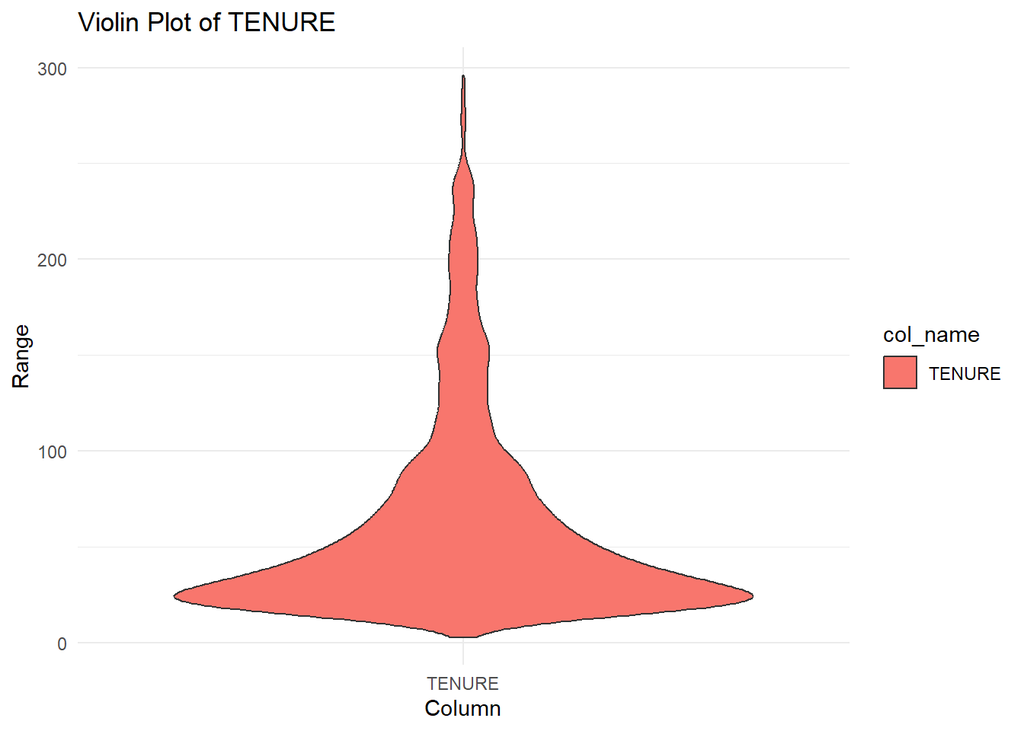

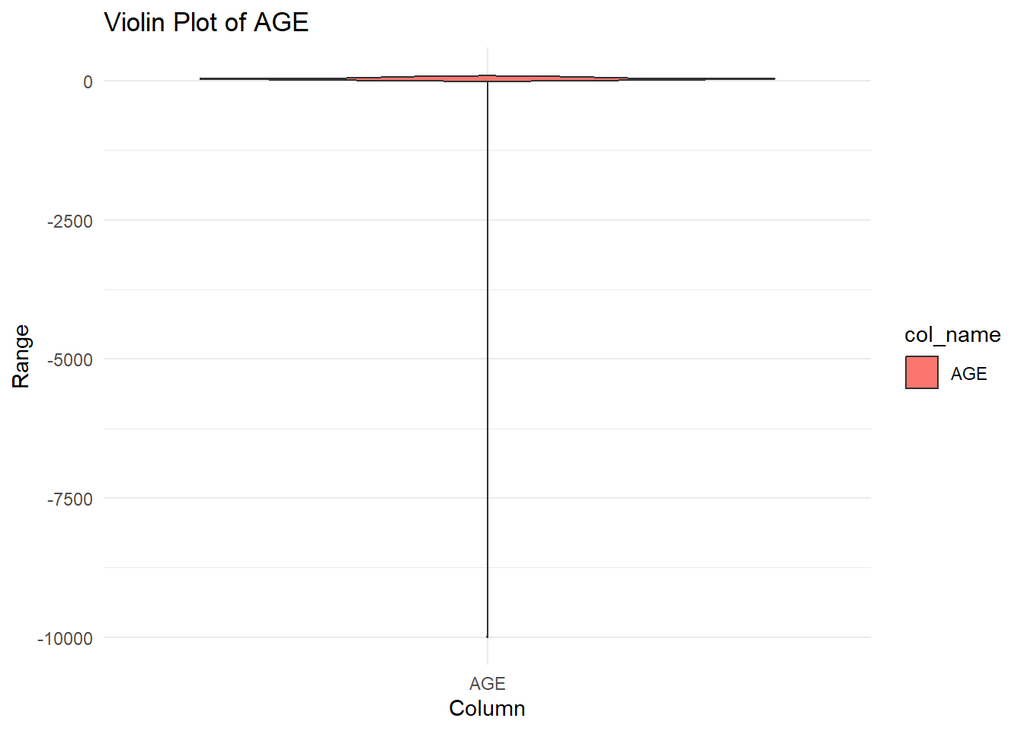

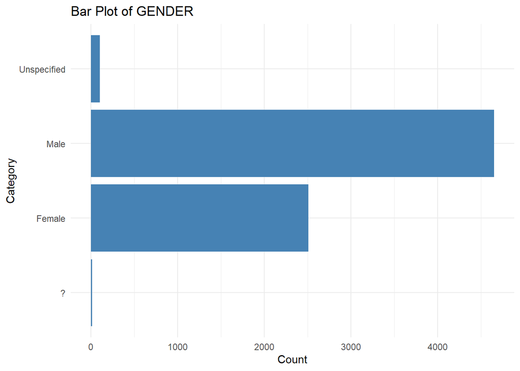

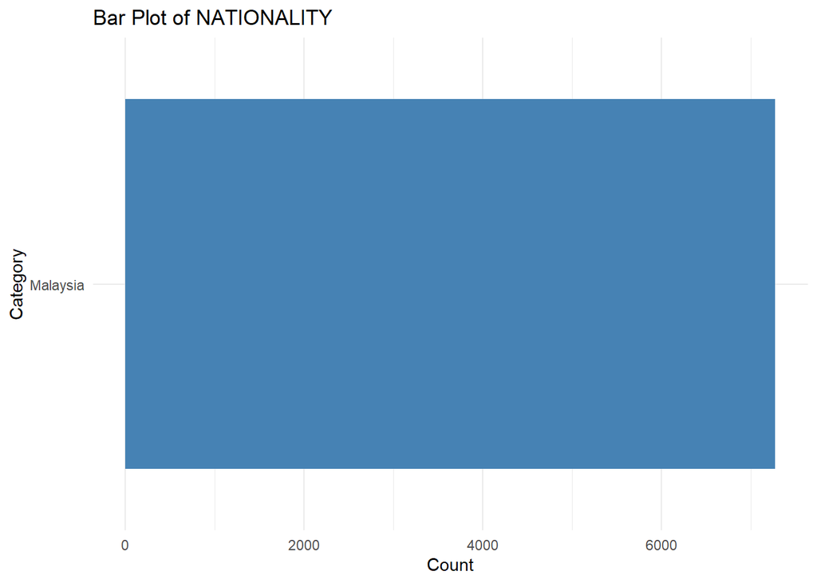

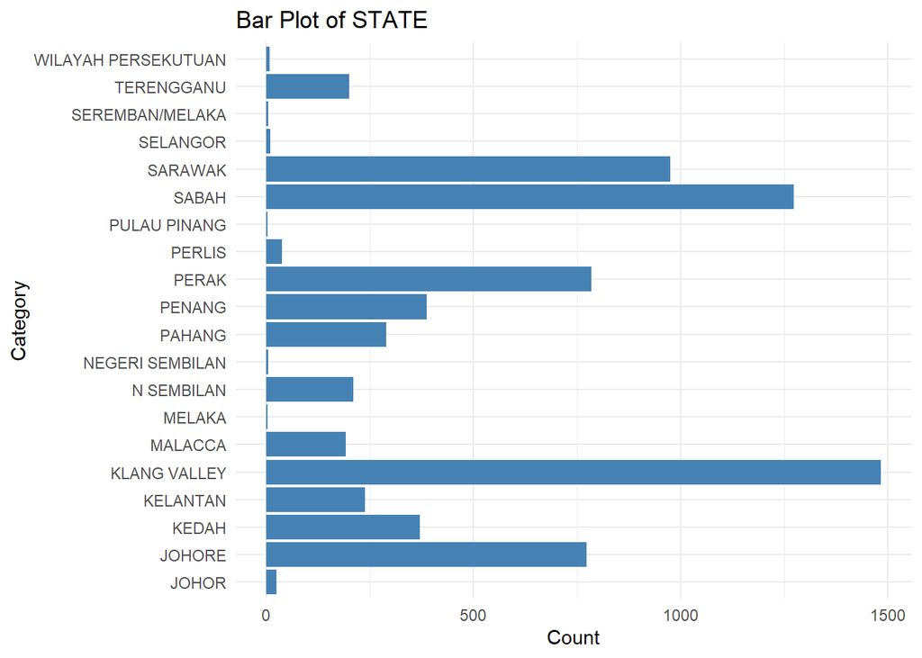

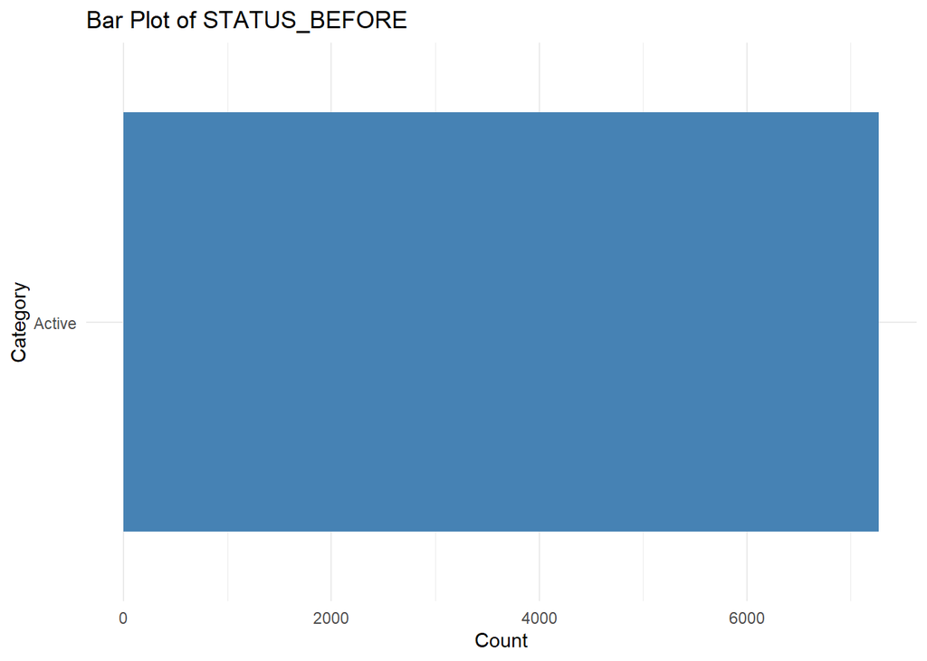

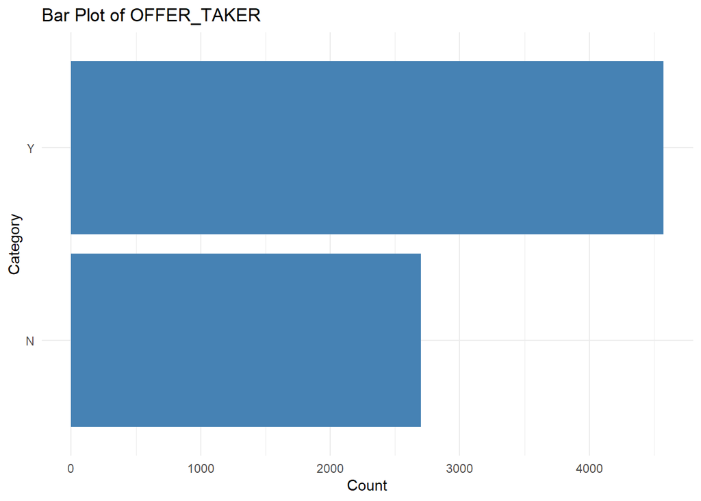

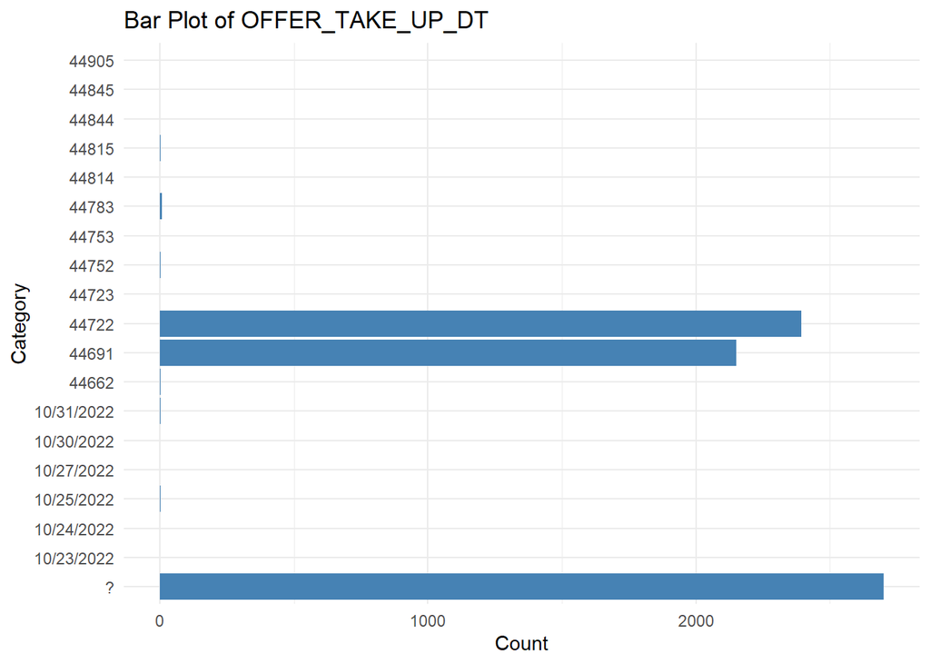

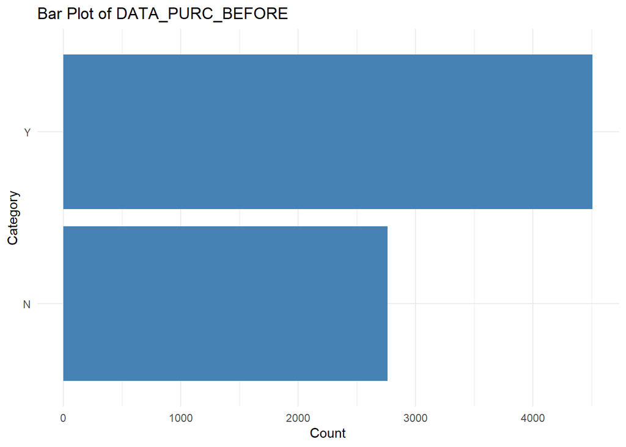

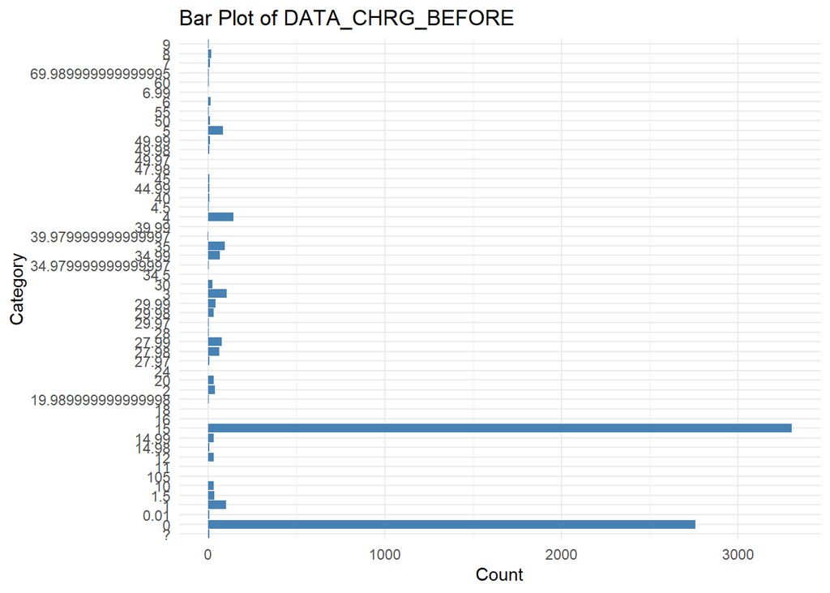

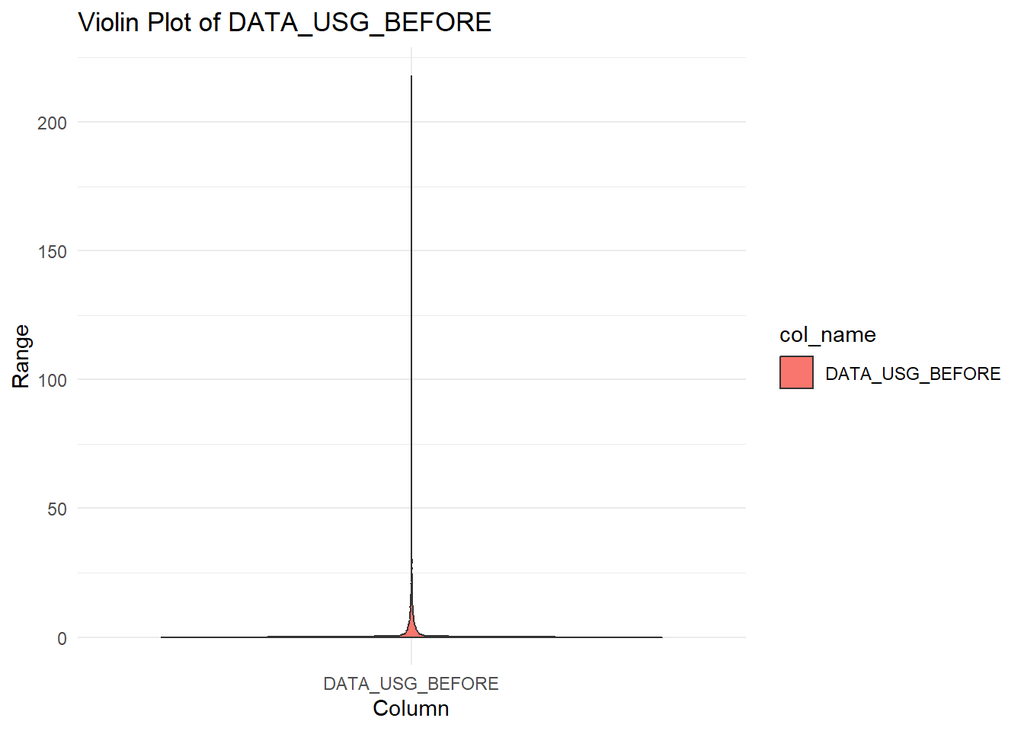

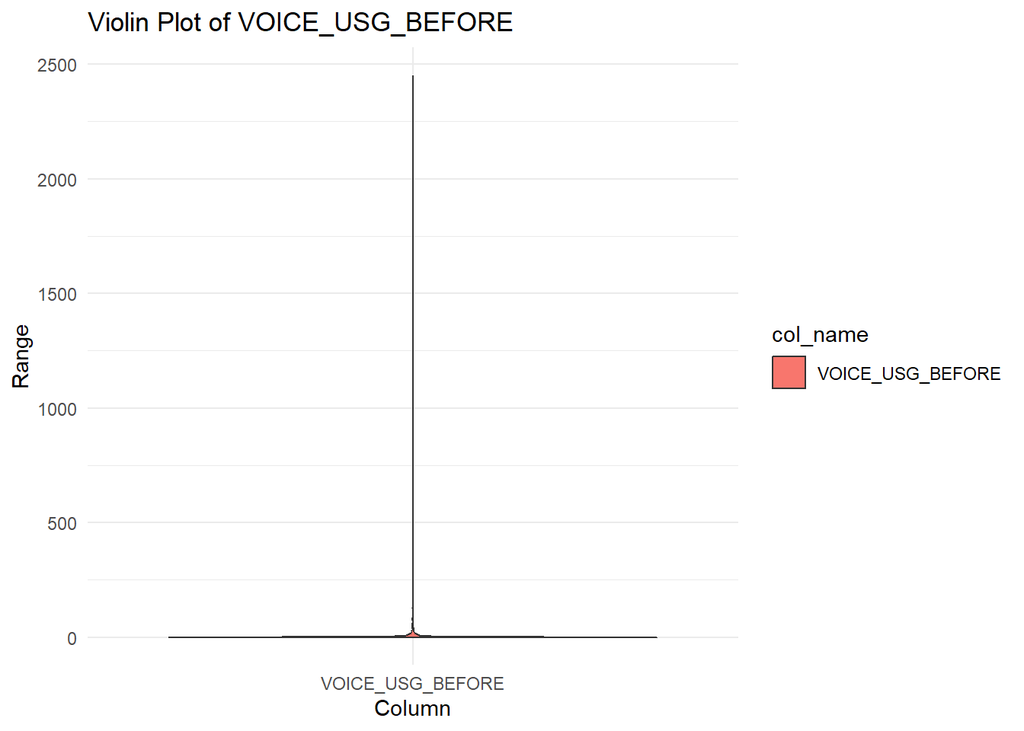

[4 more figures not shown]

From the plots, there are some numeric columns should be in violin plot but identified as bar chart. This occurred may due to the inconsistent data type in numeric columns which need to undergo data preprocessing to clean the data.

## Data Preprocessing

From previous section, there are certain parameters requires data cleaning to ensure the data quality. The first step is to remove the unnecessary column that cannot be used to differentiate the offer taker for telco campaign, which are the `NATIONALITY`, `STATUS_BEFORE` and `OFFER_TAKE_UP_DT`.

```r
# drop columns
dataframe = subset(dataframe, select = -c(NATIONALITY, STATUS_BEFORE, OFFER_TAKE_UP_DT))
```

The next step is to cater the irrelevant and missing data like `?` and `-9999` within the dataframe by replacing these values with `NA` value. The numeric value also standardized into 2 decimal points.

```r
# replace "?" and "-9999" values to "NA"
dataframe = replace(dataframe, dataframe=='?', NA)
dataframe = replace(dataframe, dataframe=='-9999', NA)

# format the numeric into 2 decimal points
dataframe$DATA_CHRG_BEFORE = round(as.numeric(dataframe$DATA_CHRG_BEFORE), 2)
dataframe$RLD_AMT_BEFORE = round(as.numeric(dataframe$RLD_AMT_BEFORE), 2)
dataframe$CPA_RVN_BEFORE = round(as.numeric(dataframe$CPA_RVN_BEFORE), 2)
dataframe$ARPU_BEFORE = round(as.numeric(dataframe$ARPU_BEFORE), 2)
```

Check again the dataframe to identify the differences from plots.

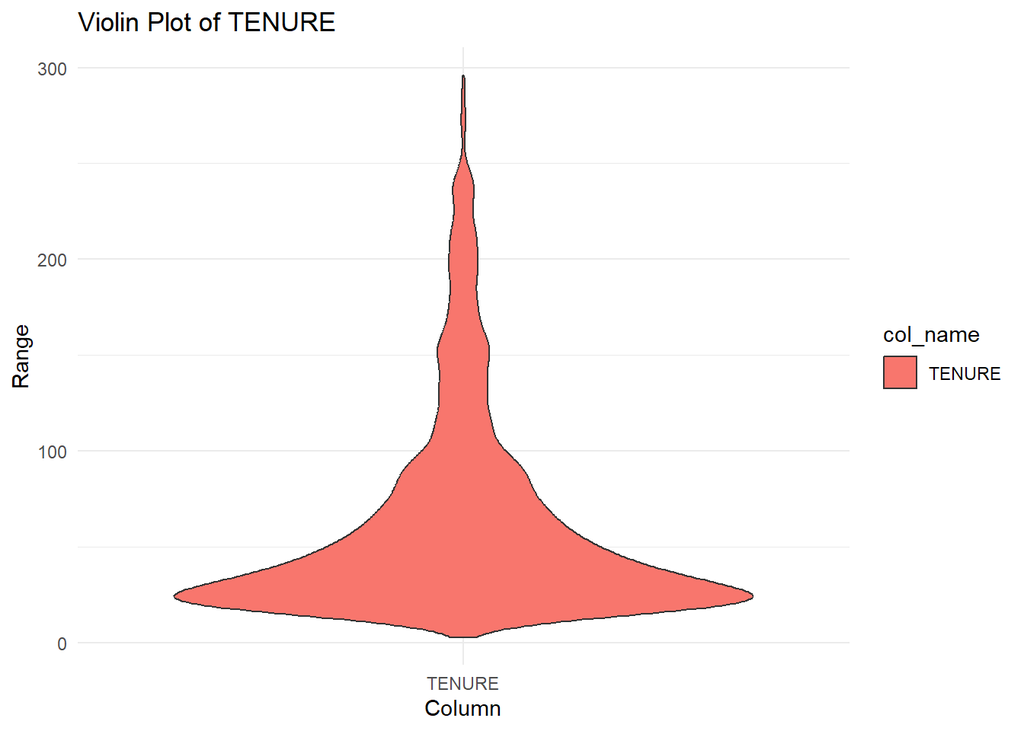

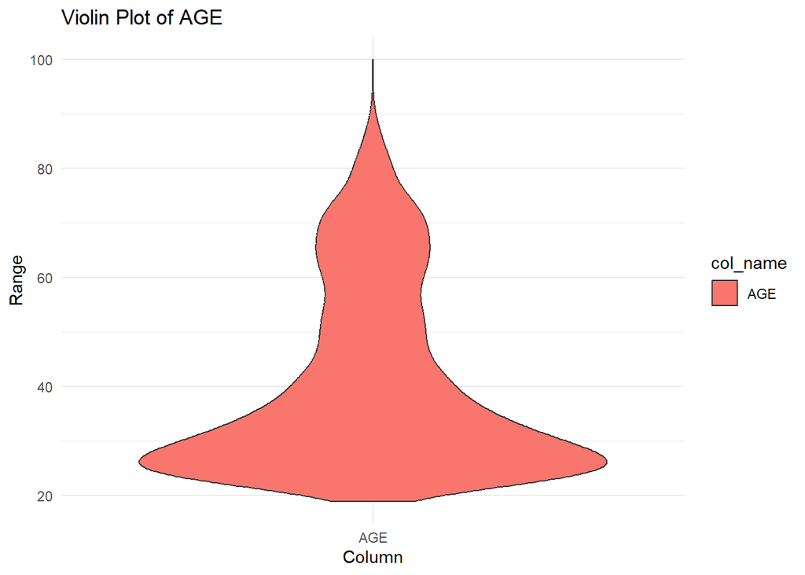

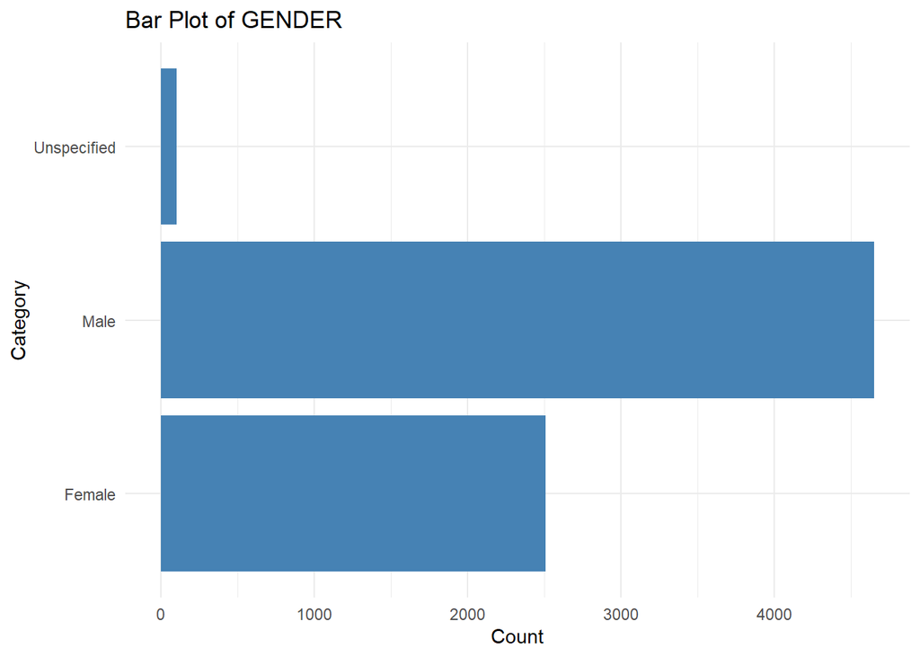

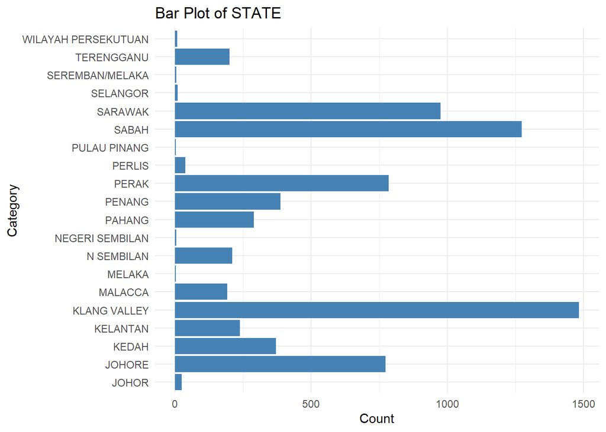

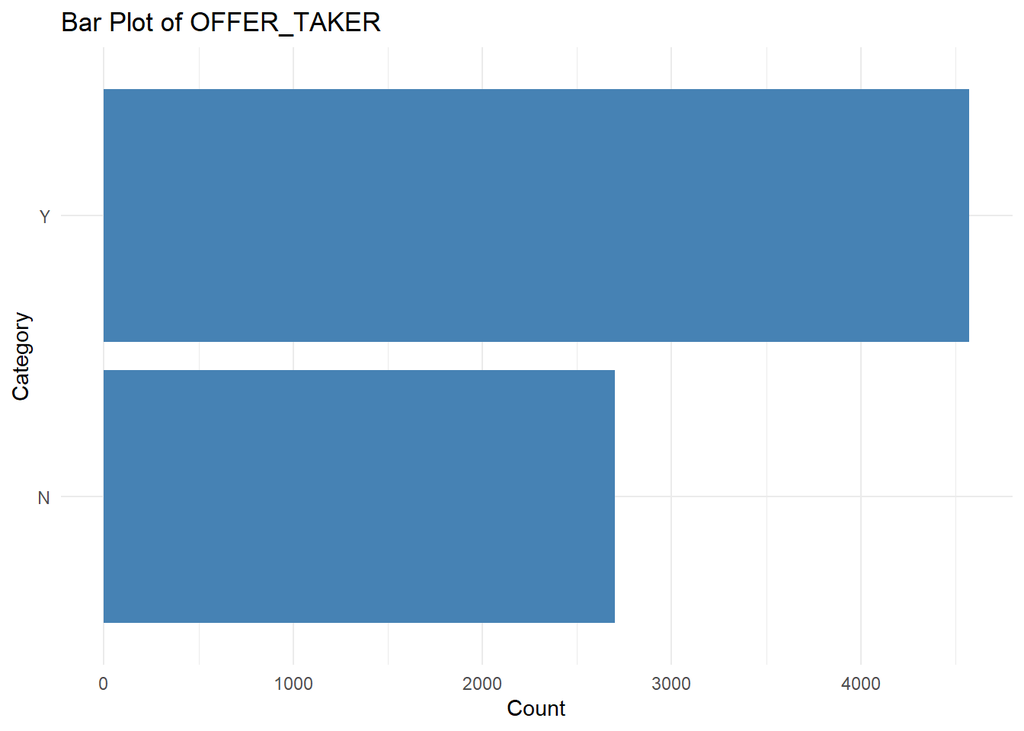

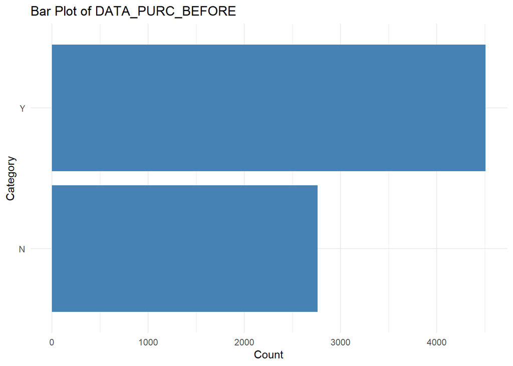

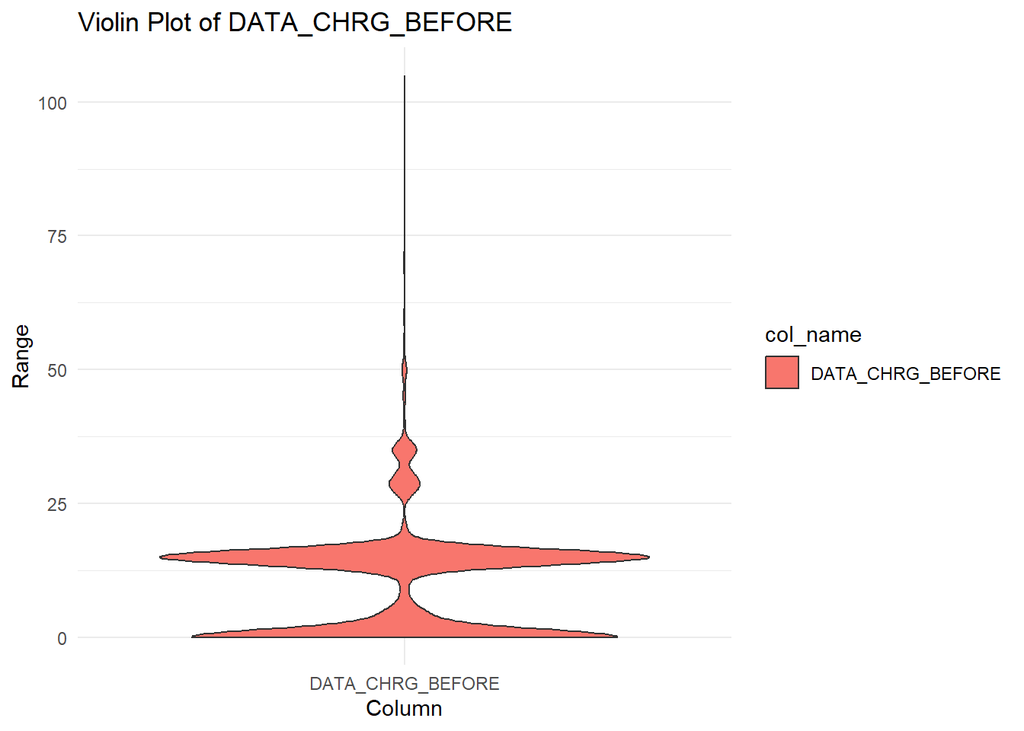

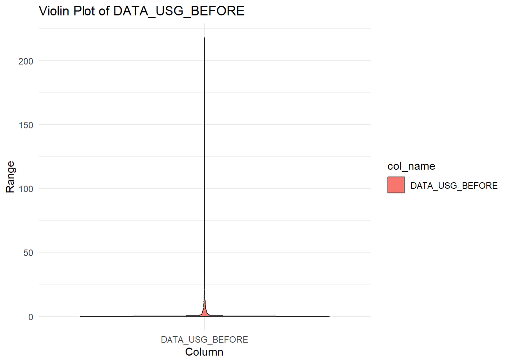

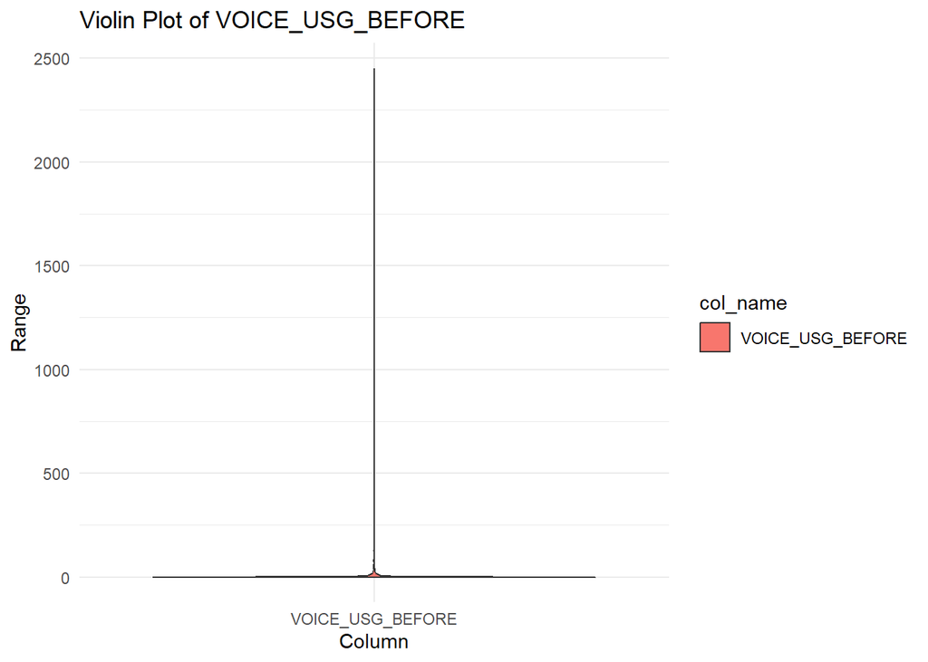

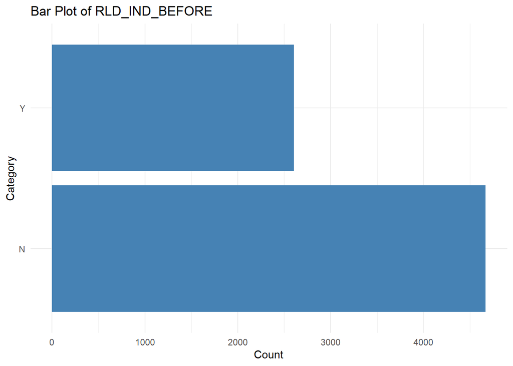

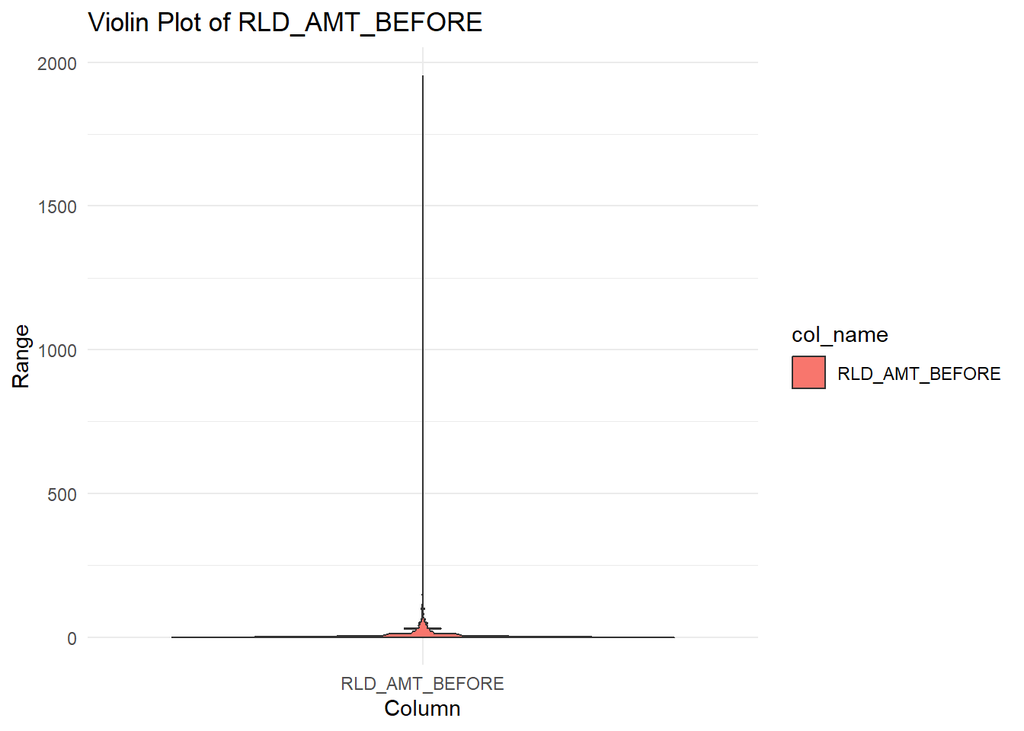

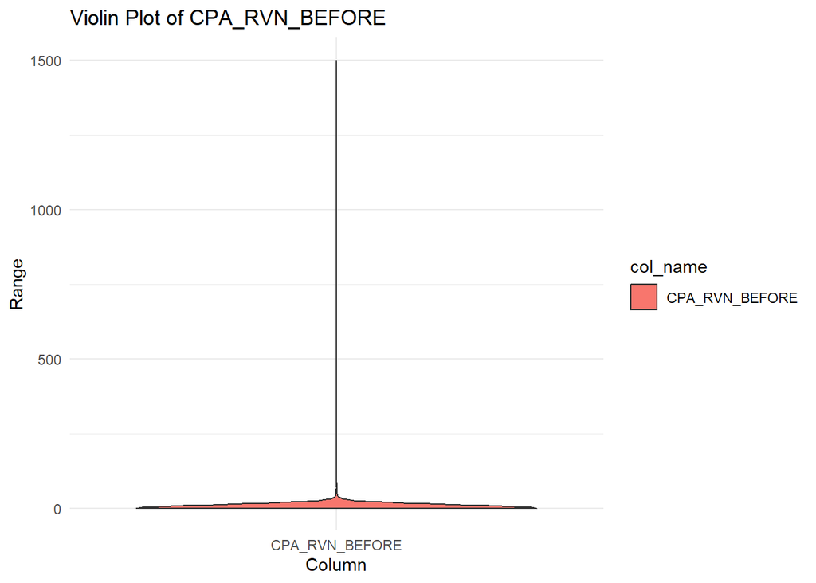

[1 more figures not shown]

Now, replace the `NA` values to 0 if the data are numeric and `"Unspecified"` in `GENDER` column.

```r
# replace all "NA" to 0 for numeric columns, "Unspecified" for GENDER column
dataframe$ARPU_BEFORE = replace(dataframe$ARPU_BEFORE, is.na(dataframe$ARPU_BEFORE), 0)
dataframe$CPA_RVN_BEFORE = replace(dataframe$CPA_RVN_BEFORE, is.na(dataframe$CPA_RVN_BEFORE), 0)
dataframe$RLD_AMT_BEFORE = replace(dataframe$RLD_AMT_BEFORE, is.na(dataframe$RLD_AMT_BEFORE), 0)
dataframe$DATA_CHRG_BEFORE = replace(dataframe$DATA_CHRG_BEFORE, is.na(dataframe$DATA_CHRG_BEFORE), 0)
dataframe$AGE = replace(dataframe$AGE, is.na(dataframe$AGE), 0)

dataframe$GENDER = replace(dataframe$GENDER, is.na(dataframe$GENDER), "Unspecified")
```

Print out the remaining `NA` value that persist in the dataframe.

```r
# check na occurrence again
null_counts = colSums(is.na(dataframe))
print(null_counts)
```

```
##           TENURE              AGE           GENDER            STATE
##                0                0                0                0
##      OFFER_TAKER DATA_PURC_BEFORE DATA_CHRG_BEFORE  DATA_USG_BEFORE
##                0                0                0                0
## VOICE_USG_BEFORE   RLD_IND_BEFORE   RLD_AMT_BEFORE   CPA_RVN_BEFORE
##                0                0                0                0
##      ARPU_BEFORE
##                0
```

Check the unique value within `STATE` column.

```r
print(unique(dataframe$STATE))
```

```
##  [1] "JOHORE"              "PAHANG"              "KLANG VALLEY"
##  [4] "SABAH"               "PERAK"               "PENANG"
##  [7] "MELAKA"              "JOHOR"               "SARAWAK"
## [10] "KELANTAN"            "KEDAH"               "MALACCA"
## [13] "PERLIS"              "N SEMBILAN"          "TERENGGANU"
## [16] "WILAYAH PERSEKUTUAN" "SEREMBAN/MELAKA"     "NEGERI SEMBILAN"
## [19] "SELANGOR"            "PULAU PINANG"
```

There are duplicated state name which are not standardized. Reclassify the data in the `STATE` column to get the correct representation of state name.

```r
#alter state columns
dataframe$STATE[dataframe$STATE == "JOHORE"] = "JOHOR"
dataframe$STATE[dataframe$STATE == "KLANG VALLEY"] = "WILAYAH PERSEKUTUAN"
dataframe$STATE[dataframe$STATE == "MALACCA"] = "MELAKA"
dataframe$STATE[dataframe$STATE == "N SEMBILAN"] = "NEGERI SEMBILAN"
dataframe$STATE[dataframe$STATE == "PULAU PINANG"] = "PENANG"
dataframe$STATE[dataframe$STATE == "SEREMBAN/MELAKA"] = "MELAKA"
print(unique(dataframe$STATE))
```

```
##  [1] "JOHOR"               "PAHANG"              "WILAYAH PERSEKUTUAN"
##  [4] "SABAH"               "PERAK"               "PENANG"
##  [7] "MELAKA"              "SARAWAK"             "KELANTAN"
## [10] "KEDAH"               "PERLIS"              "NEGERI SEMBILAN"
## [13] "TERENGGANU"          "SELANGOR"
```

Check again the data structure for dataframe.

```r
str(dataframe)
```

```
## tibble [7,272 × 13] (S3: tbl_df/tbl/data.frame)
##  $ TENURE          : num [1:7272] 90 204 120 199 30 16 86 34 12 35 ...
##  $ AGE             : num [1:7272] 28 81 84 82 0 82 82 85 85 88 ...
##  $ GENDER          : chr [1:7272] "Female" "Male" "Male" "Male" ...
##  $ STATE           : chr [1:7272] "JOHOR" "PAHANG" "WILAYAH PERSEKUTUAN" "PAHANG" ...
##  $ OFFER_TAKER     : chr [1:7272] "Y" "Y" "N" "Y" ...
##  $ DATA_PURC_BEFORE: chr [1:7272] "Y" "N" "N" "Y" ...
##  $ DATA_CHRG_BEFORE: num [1:7272] 15 0 0 15 0 15 0 0 0 0 ...
##  $ DATA_USG_BEFORE : num [1:7272] 0 0 0 0 6.53 ...
##  $ VOICE_USG_BEFORE: num [1:7272] 732.4 49.9 17.1 16.2 14.2 ...
##  $ RLD_IND_BEFORE  : chr [1:7272] "N" "N" "N" "N" ...
##  $ RLD_AMT_BEFORE  : num [1:7272] 0 0 0 0 0 0 0 0 0 0 ...
##  $ CPA_RVN_BEFORE  : num [1:7272] 0 0 0 0 0 0 0 0 0 0 ...
##  $ ARPU_BEFORE     : num [1:7272] 0 13.65 4.32 4.68 0 ...
```

To find out the correlation of each feature, the categorical variables like `GENDER`, `STATE`, `DATA_PURC_BEFORE` and `RLD_IND_BEFORE` needed to be convert into numeric type by applying one-hot encoding.

```r
# one-hot the categorical variables
cols_to_encode = c("GENDER", "STATE", "DATA_PURC_BEFORE", "RLD_IND_BEFORE")
one_hot = dummyVars(" ~ .", data = dataframe[, cols_to_encode])
encoded_df = data.frame(predict(one_hot, newdata = dataframe))
head(encoded_df, 10)
```

```
##    GENDERFemale GENDERMale GENDERUnspecified STATEJOHOR STATEKEDAH
## 1             1          0                 0          1          0
## 2             0          1                 0          0          0
## 3             0          1                 0          0          0
## 4             0          1                 0          0          0
## 5             0          0                 1          0          0
## 6             0          1                 0          0          0
## 7             1          0                 0          0          0
## 8             1          0                 0          0          0
## 9             0          1                 0          0          0
## 10            0          1                 0          0          0
##    STATEKELANTAN STATEMELAKA STATENEGERI.SEMBILAN STATEPAHANG STATEPENANG
## 1              0           0                    0           0           0
## 2              0           0                    0           1           0
## 3              0           0                    0           0           0
```

[output cut: 40 more lines]

### Feature Selection

```r
# correlation check for non categorical and plot heatmap
non_encoded_cols = setdiff(colnames(dataframe), cols_to_encode)
test_df = dataframe[, non_encoded_cols]
test_df = subset(test_df, select = -OFFER_TAKER)
```

#### Heatmap

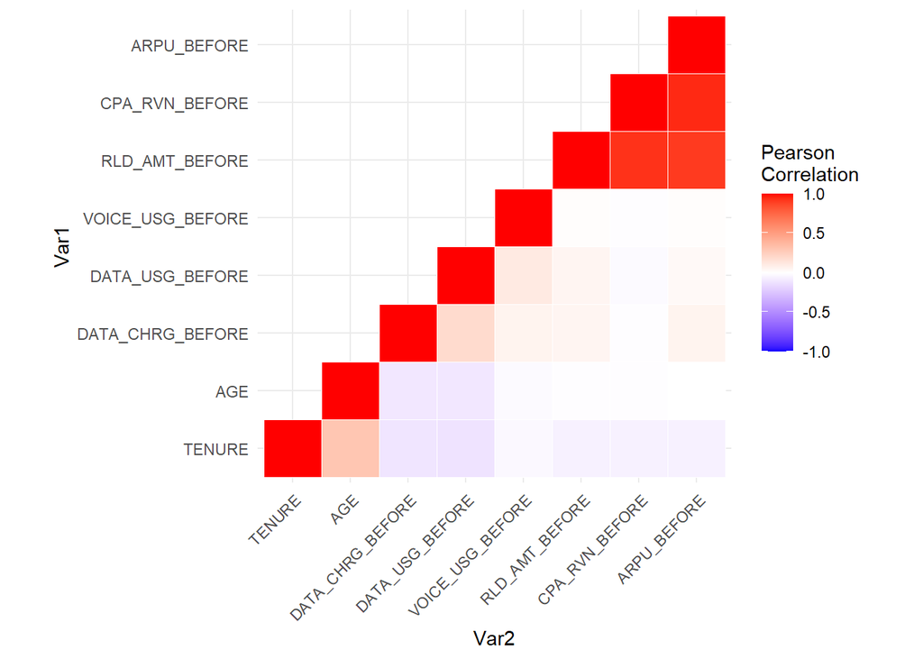

## Modeling

In order to predict which customers will opt-in for the migration campaign, a classification model will be trained. Additionally, a regression model will be utilized to estimate the revenue generated from data usage prior to the campaign.

### Classification

Before training a classification model, the high correlation columns will be removed and combine with the one-hot columns from previous section.

```r
# drop high correlation column and combine one hot encode column
merged_df = cbind(dataframe[, non_encoded_cols], encoded_df)
final_df = subset(merged_df, select = c(-CPA_RVN_BEFORE, -ARPU_BEFORE))
print(colnames(final_df))
```

```
##  [1] "TENURE"                   "AGE"
##  [3] "OFFER_TAKER"              "DATA_CHRG_BEFORE"
##  [5] "DATA_USG_BEFORE"          "VOICE_USG_BEFORE"
##  [7] "RLD_AMT_BEFORE"           "GENDERFemale"
##  [9] "GENDERMale"               "GENDERUnspecified"
## [11] "STATEJOHOR"               "STATEKEDAH"
## [13] "STATEKELANTAN"            "STATEMELAKA"
## [15] "STATENEGERI.SEMBILAN"     "STATEPAHANG"
## [17] "STATEPENANG"              "STATEPERAK"
## [19] "STATEPERLIS"              "STATESABAH"
## [21] "STATESARAWAK"             "STATESELANGOR"
## [23] "STATETERENGGANU"          "STATEWILAYAH.PERSEKUTUAN"
## [25] "DATA_PURC_BEFOREN"        "DATA_PURC_BEFOREY"
## [27] "RLD_IND_BEFOREN"          "RLD_IND_BEFOREY"
```

Assign the target variable

```r
#assign target
final_df$target = ifelse(final_df$OFFER_TAKER == "Y", 1, 0)
final_df = subset(final_df, select = -OFFER_TAKER)
head(final_df, 10)
```

```
##    TENURE AGE DATA_CHRG_BEFORE DATA_USG_BEFORE VOICE_USG_BEFORE RLD_AMT_BEFORE
## 1      90  28               15        0.000000         732.3833              0
## 2     204  81                0        0.000000          49.8667              0
## 3     120  84                0        0.000000          17.1500              0
## 4     199  82               15        0.000000          16.2000              0
## 5      30   0                0        6.525621          14.1500              0
## 6      16  82               15        0.018472          13.5834              0
## 7      86  82                0        0.000000          10.0333              0
## 8      34  85                0        0.000000           8.1667              0
## 9      12  85                0        0.001009           6.5667              0
## 10     35  88                0        0.000000           4.7667              0
##    GENDERFemale GENDERMale GENDERUnspecified STATEJOHOR STATEKEDAH
## 1             1          0                 0          1          0
## 2             0          1                 0          0          0
## 3             0          1                 0          0          0
```

[output cut: 51 more lines]

Split the dataframe to train and test set

```r
# Split the data into training and testing sets
train_idx = createDataPartition(final_df$target, p = 0.8, list = FALSE)
train_data = final_df[train_idx,]
test_data = final_df[-train_idx,]
```

#### Random Forest Classifier selected as classification model

```r
# Train the Random Forest Classifier
classifier_RF = randomForest(x = train_data[, -ncol(train_data)],
                             y = as.factor(train_data$target),
                             ntree = 500,
                             importance = TRUE)

# Make predictions on the test data
preds = predict(classifier_RF, newdata = test_data[, -ncol(test_data)])

# Calculate the confusion matrix/ accuracy of the predictions
conf_mat = table(preds, test_data$target)
accuracy = sum(diag(conf_mat)) / sum(conf_mat)

# print out the model's hyperparameter
cat("Random Forest Classifier's Hyperparameter:\n")
```

```
## Random Forest Classifier's Hyperparameter:
```

```r
print(classifier_RF)
```

```
##
## Call:
##  randomForest(x = train_data[, -ncol(train_data)], y = as.factor(train_data$target),      ntree = 500, importance = TRUE)
##                Type of random forest: classification
##                      Number of trees: 500
## No. of variables tried at each split: 5
##
##         OOB estimate of  error rate: 8.59%
## Confusion matrix:
##      0    1 class.error
## 0 2056  109  0.05034642
## 1  391 3262  0.10703531
```

Print out the output for Random Forest Classifier’s confusion matrix and the accuracy.

```
## Confusion Matrix (Prediction):
```

```
##
## preds   0   1
##     0 508 103
##     1  26 817
```

```
## Accuracy of Random Forest Classifier: 0.911
```

#### KNN Classifier selected as classification model

```r
# Train the KNN Classifier
classifier_KNN <- train(x = train_data[, -ncol(train_data)],
                        y = as.factor(train_data$target),
                        method = "knn",
                        trControl = trainControl(method = "none"),
                        preProcess = c("center", "scale"))

# Make predictions on the test data
preds_KNN <- predict(classifier_KNN, newdata = test_data[, -ncol(test_data)])

# Calculate the confusion matrix/ accuracy of the predictions
conf_mat_KNN <- table(preds_KNN, test_data$target)
accuracy_KNN <- sum(diag(conf_mat_KNN)) / sum(conf_mat_KNN)

# print out the model's hyperparameter
cat("KNN Classifier's Hyperparameter:\n")
```

```
## KNN Classifier's Hyperparameter:
```

```r
print(classifier_KNN)
```

```
## k-Nearest Neighbors
##
## 5818 samples
##   27 predictor
##    2 classes: '0', '1'
##
## Pre-processing: centered (27), scaled (27)
## Resampling: None
```

Print out the output for KNN Classifier, confusion matrix and the accuracy.

```
## Confusion Matrix (Prediction):
```

```
##
## preds_KNN   0   1
##         0 456 104
##         1  78 816
```

```
## Accuracy of KNN Classifier: 0.875
```

#### SVM Classifier selected as classification model

```r
# Train the SVM Classifier
classifier_SVM <- svm(x = train_data[, -ncol(train_data)],
                      y = as.factor(train_data$target),
                      kernel = "radial")

# Make predictions on the test data
preds_SVM <- predict(classifier_SVM, newdata = test_data[, -ncol(test_data)])

# Calculate the confusion matrix/ accuracy of the predictions
conf_mat_SVM <- table(preds_SVM, test_data$target)
accuracy_SVM <- sum(diag(conf_mat_SVM)) / sum(conf_mat_SVM)

# print out the model's hyperparameter
cat("SVM Classifier's Hyperparameter:\n")
```

```
## SVM Classifier's Hyperparameter:
```

```r
print(classifier_SVM)
```

```
##
## Call:
## svm.default(x = train_data[, -ncol(train_data)], y = as.factor(train_data$target),
##     kernel = "radial")
##
##
## Parameters:
##    SVM-Type:  C-classification
##  SVM-Kernel:  radial
##        cost:  1
##
## Number of Support Vectors:  1690
```

Print out the output for SVM Classifier, confusion matrix and the accuracy.

```
## Confusion Matrix (Prediction):
```

```
##
## preds_SVM   0   1
##         0 500 138
##         1  34 782
```

```
## Accuracy of svm Classifier: 0.882
```

Throughout the performance for these classifiers, Random Forest classifier has the highest accuracy hence it is selected as the best classification model.

#### Feature Importance for Selected Classifiers

Display all feature importance for Random Forest Classifiers.

```r
#feature important
imp_RF <- importance(classifier_RF)
cat("Random Forest Feature Importance:\n")
```

```
## Random Forest Feature Importance:
```

```r
print(imp_RF)
```

```
##                                    0           1 MeanDecreaseAccuracy
## TENURE                   11.97715665  35.1891136          32.11374571
## AGE                       7.46273280   5.1610021          10.43911505
## DATA_CHRG_BEFORE         28.74227276 133.6120997          71.41718790
## DATA_USG_BEFORE          29.29221773   0.2469145          31.21851197
## VOICE_USG_BEFORE         35.49131563   5.4277816          34.64161020
## RLD_AMT_BEFORE           22.70401640  45.4516805          39.08703302
## GENDERFemale              3.60989470   0.9622351           3.82999906
## GENDERMale                2.85370618  -0.2134767           2.61189844
## GENDERUnspecified         1.69125655   2.2964871           2.54227990
## STATEJOHOR               -1.68389182   0.4287480          -1.08186661
## STATEKEDAH                0.04297138  -0.5333321          -0.29095293
## STATEKELANTAN            -0.06786768  -1.9758426          -1.32433085
## STATEMELAKA               0.97818427  -2.9835035          -0.78198620
## STATENEGERI.SEMBILAN     -5.79751858  -1.9762758          -5.76420989
## STATEPAHANG              -1.28720445  -1.1889965          -1.76645438
## STATEPENANG               1.27240865   3.1149979           3.11797908
## STATEPERAK               -4.23180822  -2.6789454          -5.28371394
## STATEPERLIS              -0.63679164   4.5613113           2.50636494
## STATESABAH               -3.09295213   7.5360485           1.82930846
## STATESARAWAK              0.45965862   0.5161960           0.70793221
## STATESELANGOR            -4.02116499  -1.3264338          -4.33384980
## STATETERENGGANU          -0.88316857   1.9153341           0.55213746
## STATEWILAYAH.PERSEKUTUAN  3.08101458  -3.7025310           0.02181952
## DATA_PURC_BEFOREN        15.49310383  17.4661423          18.44771209
## DATA_PURC_BEFOREY        13.75789349  15.9008650          16.87699351
## RLD_IND_BEFOREN          15.21142528  14.1529849          18.60399640
## RLD_IND_BEFOREY          15.23695507  12.2213108          17.54899514
##                          MeanDecreaseGini
## TENURE                        154.6688232
## AGE                           102.8174824
## DATA_CHRG_BEFORE              945.8265020
## DATA_USG_BEFORE               116.5278965
## VOICE_USG_BEFORE               64.0658641
## RLD_AMT_BEFORE                126.1089673
## GENDERFemale                   11.4587965
## GENDERMale                     11.7566465
## GENDERUnspecified               3.4748545
## STATEJOHOR                      9.7683536
## STATEKEDAH                      5.8979371
## STATEKELANTAN                   4.8231371
## STATEMELAKA                     5.2357446
## STATENEGERI.SEMBILAN            5.6408603
## STATEPAHANG                     5.9904911
## STATEPENANG                     8.9793692
## STATEPERAK                      9.9264803
## STATEPERLIS                     2.5678456
## STATESABAH                     11.5356562
## STATESARAWAK                   11.8815381
## STATESELANGOR                   0.6922897
## STATETERENGGANU                 3.8324166
## STATEWILAYAH.PERSEKUTUAN       14.2099706
## DATA_PURC_BEFOREN             407.0677570
## DATA_PURC_BEFOREY             347.4831770
## RLD_IND_BEFOREN                18.5466256
## RLD_IND_BEFOREY                18.4429966
```

### Regression

```r
# drop category
non_cat_df = dataframe[, non_encoded_cols]
final_df = subset(non_cat_df, select = c(-CPA_RVN_BEFORE, -ARPU_BEFORE, -OFFER_TAKER))
print(colnames(final_df))
```

```
## [1] "TENURE"           "AGE"              "DATA_CHRG_BEFORE" "DATA_USG_BEFORE"
## [5] "VOICE_USG_BEFORE" "RLD_AMT_BEFORE"
```

Split the dataframe to train and test set

```r
# Split the data into training and testing sets
train_idx = createDataPartition(final_df$DATA_CHRG_BEFORE, p = 0.8, list = FALSE)
train_data = final_df[train_idx,]
test_data = final_df[-train_idx,]
```

Scale the train-test data and assign target for regression model

```r
# scaling
train_data_scaled = train_data %>%
  select(-DATA_CHRG_BEFORE) %>%
  scale() %>%
  as.data.frame() %>%
  cbind(train_data$DATA_CHRG_BEFORE)

colnames(train_data_scaled)[6] = "target"
```

#### Linear Regression selected as Regression Model

```r
# regression
lm_model = lm(target ~ ., data = train_data_scaled)

#predict
test_data_scaled = test_data %>%
  select(-DATA_CHRG_BEFORE) %>%
  scale() %>%
  as.data.frame() %>%
  cbind(test_data$DATA_CHRG_BEFORE)
predictions = predict(lm_model, newdata = test_data_scaled)

colnames(test_data_scaled)[6] = "target"
```

Print out the performance of model

```r
#result
RMSE = sqrt(mean((predictions - test_data_scaled$target)^2))
R2 = cor(predictions, test_data_scaled$target)^2
```

```
## Performance of Linear Regression:
##
## RMSE: 9.595885
## R-squared: 0.06333764
```

Coefficient of Linear Regression model

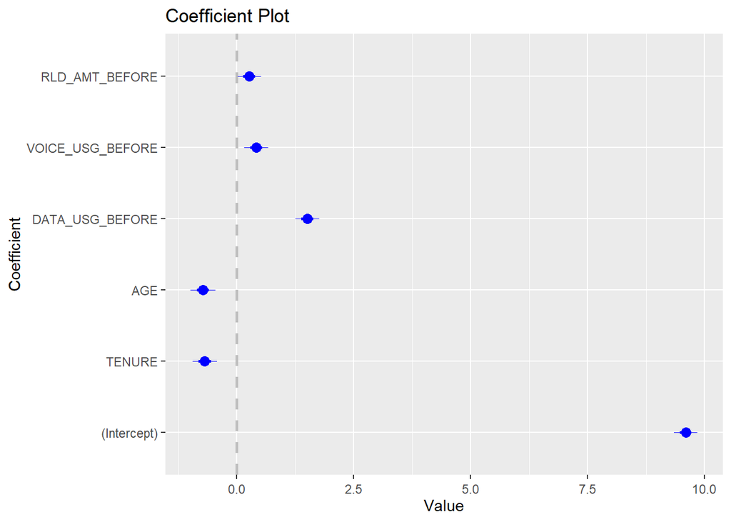

## Citation

Cote, C. (2021, January 21). What is marketing analytics?: HBS Online. Retrieved April 28, 2023, from https://online.hbs.edu/blog/post/what-is-marketing-analytics.